# Covid-19

26 de junho de 2025

## Introdução

Este trabalho tem por objetivo analisar a pandemia da COVID 19 no intervalo entre 27/03/2020 até 25/06/2020, comparar as regiões para ver a periculosidade em cada local e a relação entre os número de infectados e óbitos. Utilizamos a linguagem R para a produção deste relatório.

## Materiais e Recursos

Utilizamos dados do (DATASUS)[https://opendatasus.saude.gov.br/dataset] que foi fornecido a nós através de uma planilha no excel no arquivo “HIST_PAINEL_COVIDBR_25jun2020.xlsx” pela nossa professora de Estatística Computacional 1 a Doutora Daniela Polessa.

## Preparação dos dados

```
1 - Excluí todas as linhas que possuiam dados vazios

2 - Excluí as colunas vazias Recuperadonovos, emAcompanhamentoNovos

3 - Na coluna populacaoTCU2019 alterei os dados que estavam escritos
"10.139(17)" para "10139" para se adequar aos outros dados que estavam
em formato de números

4 - Na coluna populacaoTCU2019 alterei os dados que estavam escritos
"102.400(7)" para "102400" para se adequar aos outros dados que estavam
em formato de números

5 - Na coluna populacaoTCU2019 alterei os dados que estavam escritos
"13540 (18)" para "13540" para se adequar aos outros dados que estavam
em formato de números
```

## Preparação dos dados (Parte 1)

```
6 - Na coluna populacaoTCU2019 alterei os dados que estavam escritos
"122.197(6)" para "122197" para se adequar aos outros dados que estavam
em formato de números

7 - Na coluna populacaoTCU2019 alterei os dados que estavam escritos
"12.123(8)" para "12123" para se adequar aos outros dados que estavam
em formato de números

8 - Na coluna populacaoTCU2019 alterei os dados que estavam escritos
"15.221(12)" para "15221" para se adequar aos outros dados que estavam
em formato de números

9 - Na coluna populacaoTCU2019 alterei os dados que estavam escritos
"15.895(10)" para "15895" para se adequar aos outros dados que estavam
em formato de números
```

## Preparação dos dados (Parte 2)

```
10 - Na coluna populacaoTCU2019 alterei os dados que estavam escritos
"16.256(4)" para "16256" para se adequar aos outros dados que estavam
em formato de números

11 - Na coluna populacaoTCU2019 alterei os dados que estavam escritos
"16.979(15)" para "16979" para se adequar aos outros dados que estavam
em formato de números

12 - Na coluna populacaoTCU2019 alterei os dados que estavam escritos
"25.156(3)" para "25156" para se adequar aos outros dados que estavam
em formato de números

13 - Na coluna populacaoTCU2019 alterei os dados que estavam escritos
"32.105(2)" para "32105" para se adequar aos outros dados que estavam
em formato de números
```

## Preparação dos dados (Parte 3)

```
Foram criadas as variáveis obitosAcumuladoPelaPopulacao,
casosAcumuladosPelaPopulacao para criar as taxas de óbitos e
casos pela população. Fizemos histogramas para medir as variações e
tabelas resumindo os dados.

obitosAcumuladoPelaPopulacao = (obitosAcumulado / populacaoTCU2019) * 100000
casosAcumuladosPelaPopulacao = (casosAcumulado / populacaoTCU2019) * 100000
```

## Slide 1

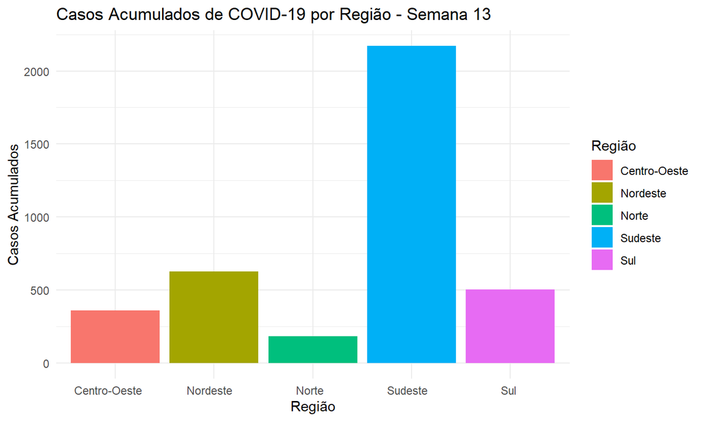

## Slide 2

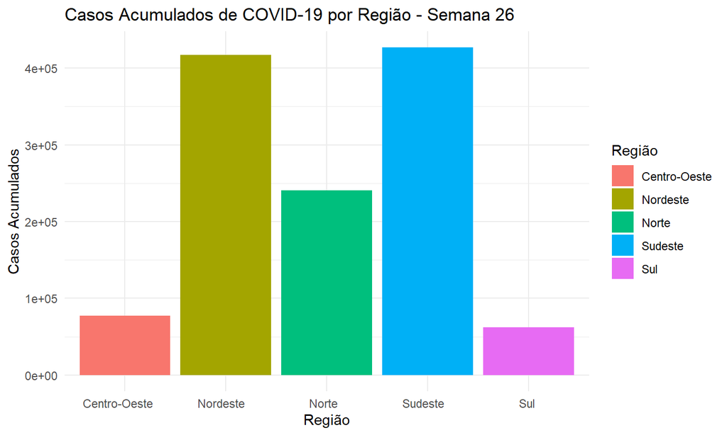

## Slide 3

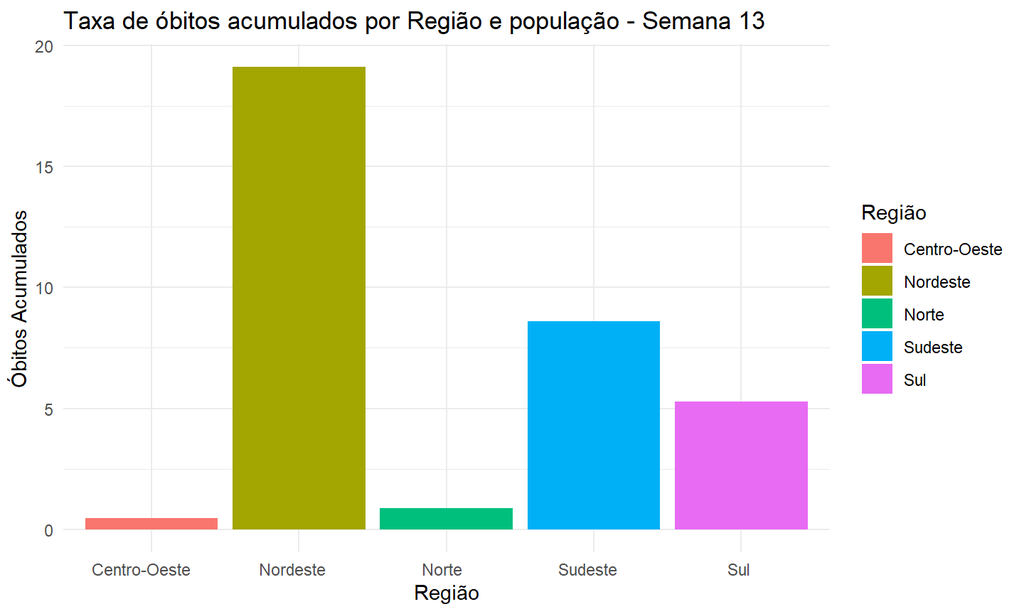

## Slide 4

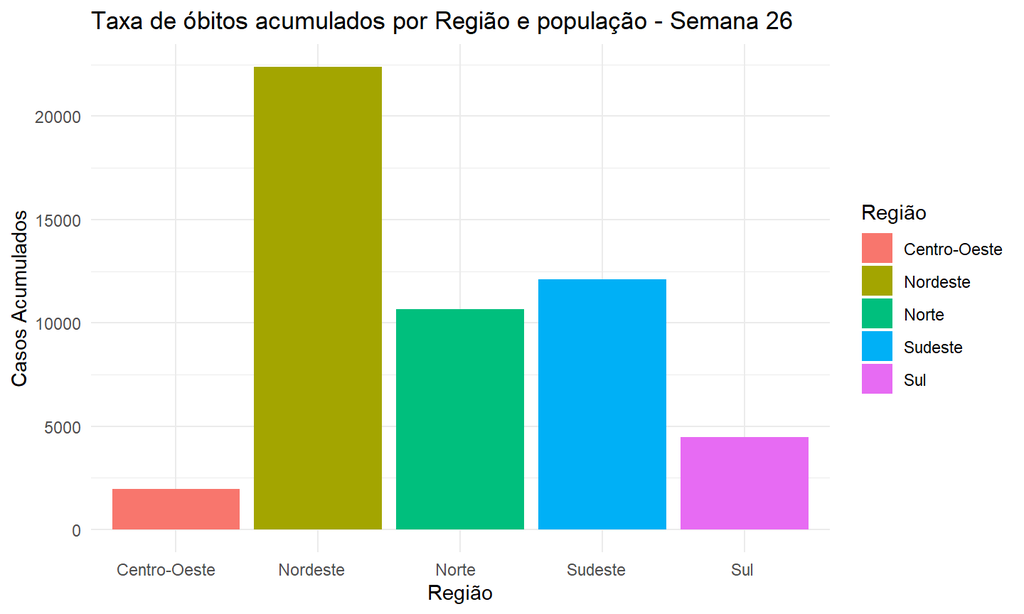

## Slide 5

```
## # A tibble: 5 × 4
##   regiao       Casos_Acumulados Obitos_Acumulados periculosidade
##   <chr>                   <dbl>             <dbl>          <dbl>
## 1 Centro-Oeste              360                 1        0.00625
## 2 Nordeste                  626                 9        0.0159
## 3 Norte                     184                 1        0.00545
## 4 Sudeste                  2171                96        0.110
## 5 Sul                       502                 5        0.0171
```

## Slide 6

```
## # A tibble: 5 × 4
##   regiao       Casos_Acumulados Obitos_Acumulados periculosidade
##   <chr>                   <dbl>             <dbl>          <dbl>
## 1 Centro-Oeste            27274               495           3.10
## 2 Nordeste               234105             11078          19.6
## 3 Norte                  140645              6777          36.9
## 4 Sudeste                238566             16818          19.3
## 5 Sul                     29864               680           2.33
```

Na semana 26 vemos o salto na região norte, reflexo da ampliação de testes como afirma a matéria do link.

https://g1.globo.com/am/amazonas/noticia/2020/05/12/em-tres-dias-am-supera-recorde-de-novos-casos-de-covid-19-em-um-unico-e-chega-a-14168-infectados-ja-sao-1098-mortes.ghtml

## Slide 7

Conclusões:

Fizemos várias comparações entre a semana 13 e a semana 26 da pandemia.

Analisando o número de casos absolutos, na semana 13 fica claro que a região sudeste foi a mais afetada, o primeiro caso foi em São Paulo[1] e por ser uma região muito povoada junto do Rio de Janeiro isso acabou puxando os números de casos. Ao chegar na semana 26 a região nordeste se mostrou tão afetada quanto.